# Education Project

## ANALYSIS

1. Data Cleaning and Preparation

Handle Missing Values: Check for any missing data and decide how to handle it (e.g., impute with mean/median, remove, etc.). Data Types Verification: Ensure each column has the correct data type (e.g., Age as an integer, Attendance (%) and Exam_Score as floats, Gender, Region, and Socioeconomic_Status as categorical variables).

2. Descriptive Statistics

Summary Statistics: Calculate mean, median, mode, standard deviation, and range for numerical columns like Age, Attendance (%), and Exam_Score. Frequency Counts: For categorical columns (Gender, Region, Socioeconomic_Status), determine the distribution of categories. Data Distribution: Visualize the distribution of numerical data using histograms or box plots.

3. Data Visualization

Bar Charts: For categorical data such as Gender, Region, and Socioeconomic_Status, to visualize the number of students in each category. Box Plots: To compare Exam_Score distributions across categories like Gender or Region. Scatter Plots: To examine relationships between Age and Exam_Score or Attendance (%) and Exam_Score. Heatmaps: To display the correlation between numerical variables like Age, Attendance (%), and Exam_Score.

4. Correlation Analysis

Correlation Matrix: Calculate and visualize the correlation between Age, Attendance (%), and Exam_Score to identify relationships. Hypothesis Testing: Use statistical tests (e.g., t-tests, chi-square tests) to examine if relationships between categorical and numerical variables are significant.

5. Comparative Analysis

Gender Differences: Analyze if there are significant differences in Attendance (%) or Exam_Score between genders. Regional Differences: Compare Exam_Score and Attendance (%) across different Region categories. Socioeconomic Status Impact: Study how Socioeconomic_Status affects Exam_Score or Attendance (%).

6. Predictive Analysis (if applicable)

Regression Analysis: If you want to predict Exam_Score, consider using regression models with Age, Attendance (%), Gender, Region, and Socioeconomic_Status as predictors. Classification Models: If you want to classify students into categories based on Exam_Score, consider logistic regression or decision trees.

7. Clustering Analysis

Perform clustering (e.g., K-means) on students based on numerical attributes like Attendance (%) and Exam_Score to identify patterns or groups.

```python
from csv import reader
import plotly.express as ex
import pandas as pd
import matplotlib.pyplot as plt
import seaborn as sns
import numpy as np
import statistics
from collections import Counter
plt.style.use('seaborn-v0_8-darkgrid')
```

```python
Education = pd.read_csv('education_data.csv')
print(Education.head())
```

```
   Student_ID  Age  Gender  Attendance (%)  Exam_Score    Region  \
0        1001   16  Female              66          65  Suburban
1        1002   15    Male              96          81  Suburban
2        1003   15  Female              74          68  Suburban
3        1004   17  Female              51          63     Rural
4        1005   16    Male              54          77     Rural

  Socioeconomic_Status
0                  Low
1               Middle
2                 High
3                 High
4               Middle
```

## CHECKING FOR MISSING DATA

```python
print(Education.isnull().sum())
```

```
Student_ID              0
Age                     0
Gender                  0
Attendance (%)          0
Exam_Score              0
Region                  0
Socioeconomic_Status    0
dtype: int64
```

## CHECKING FOR DATA TYPE

```python
Education.info()
```

```
<class 'pandas.core.frame.DataFrame'>
RangeIndex: 300 entries, 0 to 299
Data columns (total 7 columns):
 #   Column                Non-Null Count  Dtype
---  ------                --------------  -----
 0   Student_ID            300 non-null    int64
 1   Age                   300 non-null    int64
 2   Gender                300 non-null    object
 3   Attendance (%)        300 non-null    int64
 4   Exam_Score            300 non-null    int64
 5   Region                300 non-null    object
 6   Socioeconomic_Status  300 non-null    object
dtypes: int64(4), object(3)
memory usage: 16.5+ KB
```

# Age

```python
df = pd.DataFrame(Education)
mean_age = df['Age'].mean()
print("Mean Age:", mean_age)
```

```
Mean Age: 15.94
```

The mean age of students in the dataset provided is 15.94 years

# Attendance

```python
df = pd.DataFrame(Education)
mean_attendance = df['Attendance (%)'].mean()
print("Mean Attendance:", mean_attendance)
```

```
Mean Attendance: 75.24
```

```
{'whiskers': [<matplotlib.lines.Line2D at 0x2a24016f0e0>,
 'caps': [<matplotlib.lines.Line2D at 0x2a24016f680>,
 'boxes': [<matplotlib.lines.Line2D at 0x2a24016c740>],
 'medians': [<matplotlib.lines.Line2D at 0x2a24016fbc0>],
 'fliers': [<matplotlib.lines.Line2D at 0x2a24016fe60>],
 'means': []}
```

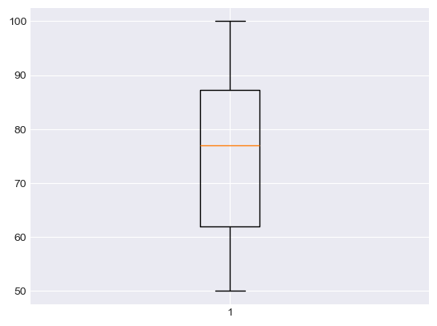

```python
plt.boxplot(x = 'Attendance (%)', data = Education)
```

Mean attendance of students in the dataset is 75.24%

# Exam score

```python
df = pd.DataFrame(Education)
mean_score = df['Exam_Score'].mean()
mean_score = round(mean_score, 2)
print("Mean Exam Score:", mean_score)
```

```
Mean Exam Score: 74.98
```

Mean Exam Score for students in the datset is approximately 75%

```
{'whiskers': [<matplotlib.lines.Line2D at 0x2a23ffa5490>,
 'caps': [<matplotlib.lines.Line2D at 0x2a23ffa58e0>,
 'boxes': [<matplotlib.lines.Line2D at 0x2a23ffa51c0>],
 'medians': [<matplotlib.lines.Line2D at 0x2a23ffa5e50>],
 'fliers': [<matplotlib.lines.Line2D at 0x2a23ffa6150>],
 'means': []}
```

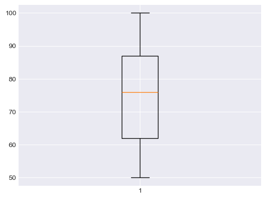

```python
plt.boxplot(x = 'Exam_Score', data = Education)
```

## CALCULATING MODE VALUES FOR AGE

```python
df = pd.DataFrame(Education)
mode_age = df['Age'].mode()
print("Mode Age:", mode_age)
```

```
Mode Age: 0    16
Name: Age, dtype: int64
```

The most common age for students in the dataset is 16 years

## CALCULATING HIGHEST VALUES ACROSS CATEGORIES

```python
df = pd.DataFrame(Education)
max_age = df['Age'].max()
print("Oldest Student:", max_age)
```

```
Oldest Student: 17
```

This tells us that the oldest student(s) across this dataset is 17 years old

```python
df = pd.DataFrame(Education)
max_attendance = df['Attendance (%)'].max()
print("Highest Atendance:", max_attendance)
```

```
Highest Atendance: 100
```

This tells us that the student with the highest attendance had a 100% record

```python
df = pd.DataFrame(Education)
max_score = df['Exam_Score'].max()
print("Highest Exam Score:", max_score)
```

```
Highest Exam Score: 100
```

This tells us that the student(s) with the highest score in the exam had a 100%

## CALCULATING LOWEST VALUES

```python
df = pd.DataFrame(Education)
min_age = df['Age'].min()
print("Youngest Student:", min_age)
```

```
Youngest Student: 15
```

This tells us that the youngest student here is 15 years old

```python
df = pd.DataFrame(Education)
min_attendance = df['Attendance (%)'].min()
print("Lowest Atendance:", min_attendance)
```

```
Lowest Atendance: 50
```

This tells us that the student with the worst attendance record had a 50% tally

```python
df = pd.DataFrame(Education)
min_score = df['Exam_Score'].min()
print("Lowest Exam Score:", min_score)
```

```
Lowest Exam Score: 50
```

This tells us that the worst exam performance in the provided dataset is 50%

Creating lists for various categories under some variables

- Socioeconomic Status

```python
low_class = []
middle_class = []
high_class = []

for index, row in Education.iterrows():
    Socioeconomic_Status = row['Socioeconomic_Status']
    if Socioeconomic_Status.strip() == 'Low':
        low_class.append('Socioeconomic_Status')
    elif Socioeconomic_Status.strip() == 'Middle':
        middle_class.append('Socioeconomic_Status')
    elif Socioeconomic_Status.strip() == 'High':
        high_class.append('Socioeconomic_Status')

print("Number of Students in Lower class:", len(low_class))
print("Number of Students in Middle class:", len(middle_class))
print("Number of Students in Higher class:", len(high_class))
```

```
Number of Students in Lower class: 99
Number of Students in Middle class: 99
Number of Students in Higher class: 102
```

```python
categories = ['low_class', 'middle_class', 'high_class']
values = [len(low_class), len(middle_class), len(high_class)]

fig = ex.pie(Education, values=values, names=categories, title='Proportions of Various Socioeconomic Status', hole=0.5)
fig.show()
```

[interactive chart not shown]

There are more students from the higher class(102) than the middle and lower classes which both have an equal number of students(99)

- Gender

```python
male = []
female = []

for index, row in Education.iterrows():
    Gender = row['Gender']
    if Gender == 'Male':
        male.append(Gender)
    elif Gender == 'Female':
        female.append('Gender')

print("Number of boys:", len(male))
print("Number of girls:", len(female))
```

```
Number of boys: 165
Number of girls: 135
```

```python
categories = ['male', 'female']
values = [len(male), len(female)]

fig = ex.pie(Education, values=values, names=categories, title='Gender Distribution', hole=0.5)
fig.show()
```

[interactive chart not shown]

There are 165 boys and 135 girls in the dataset provided

- Region

```python
suburban = []
rural = []
urban = []

for index, row in Education.iterrows():
    Region = row['Region']
    if Region == 'Suburban':
        suburban.append('Region')
    elif Region == 'Rural':
        rural.append('Region')
    elif Region == 'Urban':
        urban.append('Region')

print("Number of students from suburban regions are", len(suburban))
print("Number of students from urban regions are", len(urban))
print("Number of students from rural regions are", len(rural))
```

```
Number of students from suburban regions are 109
Number of students from urban regions are 99
Number of students from rural regions are 92
```

```python
categories = ['suburban', 'rural', 'urban']
values = [len(suburban), len(rural), len(urban)]

fig = ex.pie(Education, values=values, names=categories, title='Proportions of Various Regions', hole=0.5)
fig.show()
```

[interactive chart not shown]

## RELATIONSHIP BETWEEN VARIABLES

# Exam Score & Socioeconomic Status

```python
low_score_avg = round(Education[Education['Socioeconomic_Status'] == 'Low']['Exam_Score'].mean(), 2)
middle_score_avg = round(Education[Education['Socioeconomic_Status'] == 'Middle']['Exam_Score'].mean(), 2)
high_score_avg = round(Education[Education['Socioeconomic_Status'] == 'High']['Exam_Score'].mean(), 2)

score_avg = [low_score_avg, middle_score_avg, high_score_avg]

print("Score Average List:", score_avg)
```

```
Score Average List: [75.03, 74.28, 75.6]
```

There was not much difference in the average scores of the different socioeconomic classes where all averaged between 74-75%

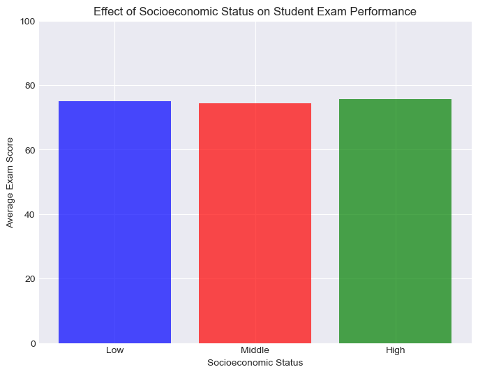

```python
statuses = ['Low', 'Middle', 'High']

plt.figure(figsize=(8,6))
bar_positions = np.arange(len(statuses))
plt.bar(bar_positions, score_avg, color = ['blue', 'red', 'green'], alpha=0.7)

plt.xticks(bar_positions, statuses)
plt.xlabel('Socioeconomic Status')
plt.ylabel('Average Exam Score')
plt.title('Effect of Socioeconomic Status on Student Exam Performance')
plt.ylim(0, 100)
plt.show()
```

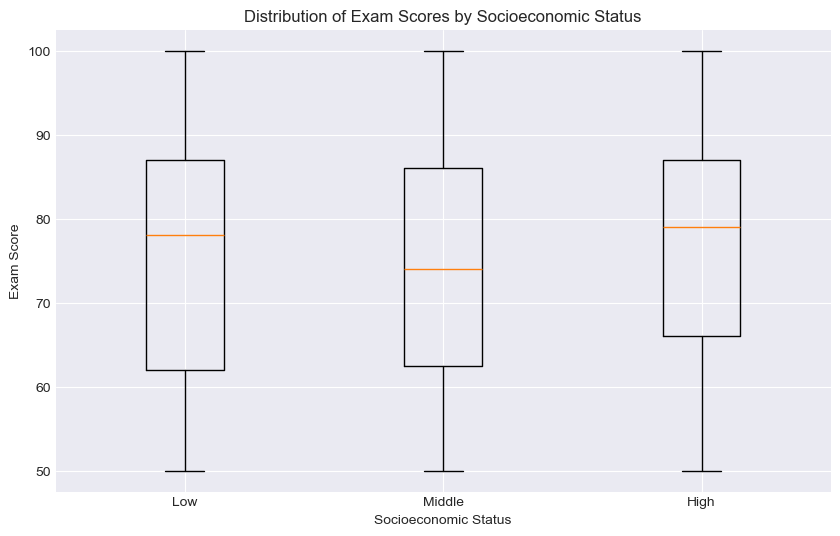

```python
low_scores = Education[Education['Socioeconomic_Status'] == 'Low']['Exam_Score']
middle_scores = Education[Education['Socioeconomic_Status'] == 'Middle']['Exam_Score']
high_scores = Education[Education['Socioeconomic_Status'] == 'High']['Exam_Score']

plt.figure(figsize=(10, 6))
plt.boxplot([low_scores, middle_scores, high_scores], tick_labels=['Low', 'Middle', 'High'])

# Add labels and title
plt.xlabel('Socioeconomic Status')
plt.ylabel('Exam Score')
plt.title('Distribution of Exam Scores by Socioeconomic Status')
plt.show()
```

## Attendance & Socioeconomic Status

```python
low_attendance_avg = round(Education[Education['Socioeconomic_Status'] == 'Low']['Attendance (%)'].mean(), 2)
middle_attendance_avg = round(Education[Education['Socioeconomic_Status'] == 'Middle']['Attendance (%)'].mean(), 2)
high_attendance_avg = round(Education[Education['Socioeconomic_Status'] == 'High']['Attendance (%)'].mean(), 2)

attendance_avg = [low_attendance_avg, middle_attendance_avg, high_attendance_avg]

print("Attendance Average List:", attendance_avg)
```

```
Attendance Average List: [74.59, 75.46, 75.66]
```

It appears that the socioeconomic classes have negligible effect on their attendane with the higher class having the highest percentage of 75.66% and lower class having the lowest of 74.59%

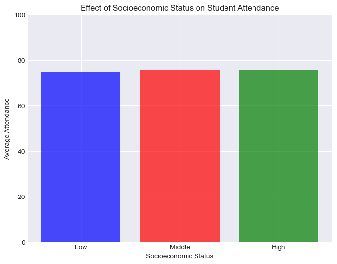

```python
statuses = ['Low', 'Middle', 'High']

plt.figure(figsize=(8,6))
bar_positions = np.arange(len(statuses))
plt.bar(bar_positions, attendance_avg, color = ['blue', 'red', 'green'], alpha=0.7)

plt.xticks(bar_positions, statuses)
plt.xlabel('Socioeconomic Status')
plt.ylabel('Average Attendance')
plt.title('Effect of Socioeconomic Status on Student Attendance')
plt.ylim(0, 100)
plt.show()
```

## Exam Score & Gender

```python
male_avg = round(Education[Education['Gender'] == 'Male']['Exam_Score'].mean(), 2)
female_avg = round(Education[Education['Gender'] == 'Female']['Exam_Score'].mean(), 2)

avg_gender_score = (male_avg, female_avg)

print("Average exam score of male students is", male_avg)
print("Average exam score of female students is", female_avg)
```

```
Average exam score of male students is 74.68
Average exam score of female students is 75.33
```

On average, female students did better than male students with an average score of 75.33% compared the the males' 74.68%

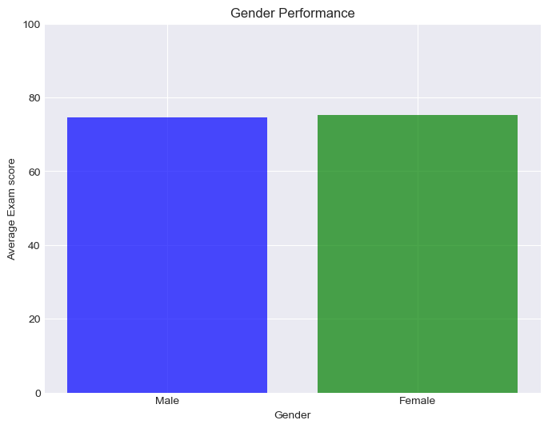

```python
statuses = ['Male', 'Female']

plt.figure(figsize=(8,6))
bar_positions = np.arange(len(statuses))
plt.bar(bar_positions, avg_gender_score, color = ['blue', 'green'], alpha=0.7)

plt.xticks(bar_positions, statuses)
plt.xlabel('Gender')
plt.ylabel('Average Exam score')
plt.title('Gender Performance')
plt.ylim(0, 100)
plt.show()
```

## Attendance & Gender

```python
male_attendance_avg = round(Education[Education['Gender'] == 'Male']['Attendance (%)'].mean(), 2)
female_attendance_avg = round(Education[Education['Gender'] == 'Female']['Attendance (%)'].mean(), 2)

avg_gender_attendance = (male_attendance_avg, female_attendance_avg)

print("Average male attendance is:", male_attendance_avg)
print("Average female attendance is:", female_attendance_avg)
```

```
Average male attendance is: 77.12
Average female attendance is: 72.94
```

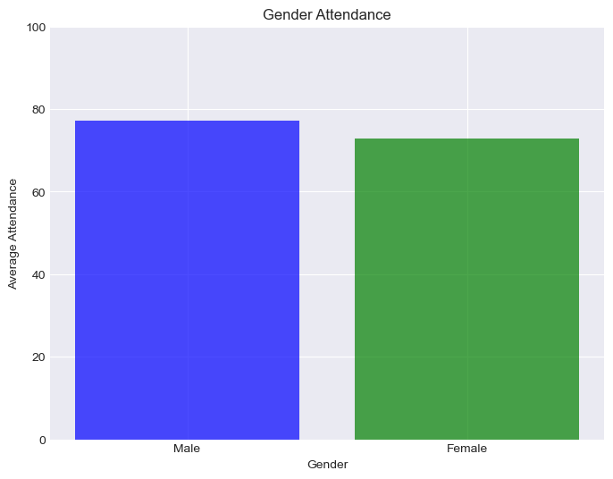

```python
statuses = ['Male', 'Female']

plt.figure(figsize=(8,6))
bar_positions = np.arange(len(statuses))
plt.bar(bar_positions, avg_gender_attendance, color = ['blue', 'green'], alpha=0.7)

plt.xticks(bar_positions, statuses)
plt.xlabel('Gender')
plt.ylabel('Average Attendance')
plt.title('Gender Attendance')
plt.ylim(0, 100)
plt.show()
```

# Region and Exam Score

```python
suburban_score_avg = round(Education[Education['Region'] == 'Suburban']['Exam_Score'].mean(), 2)
Rural_score_avg = round(Education[Education['Region'] == 'Rural']['Exam_Score'].mean(), 2)
Urban_score_avg = round(Education[Education['Region'] == 'Urban']['Exam_Score'].mean(), 2)

region_score_avg = [suburban_score_avg, Rural_score_avg, Urban_score_avg]

print("Score Average List:", region_score_avg)
```

```
Score Average List: [74.28, 77.03, 73.84]
```

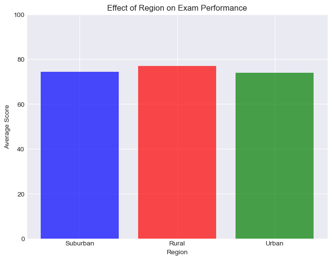

```python
statuses = ['Suburban', 'Rural', 'Urban']

plt.figure(figsize=(8,6))
bar_positions = np.arange(len(statuses))
plt.bar(bar_positions, region_score_avg, color = ['blue', 'red', 'green'], alpha=0.7)

plt.xticks(bar_positions, statuses)
plt.xlabel('Region')
plt.ylabel('Average Score')
plt.title('Effect of Region on Exam Performance')
plt.ylim(0, 100)
plt.show()
```

# Region and Attendance

```python
suburban_att_avg = round(Education[Education['Region'] == 'Suburban']['Attendance (%)'].mean(), 2)
Rural_att_avg = round(Education[Education['Region'] == 'Rural']['Attendance (%)'].mean(), 2)
Urban_att_avg = round(Education[Education['Region'] == 'Urban']['Attendance (%)'].mean(), 2)

region_att_avg = [suburban_att_avg, Rural_att_avg, Urban_att_avg]

print("Score Average List:", region_att_avg)
```

```
Score Average List: [75.34, 75.28, 75.09]
```

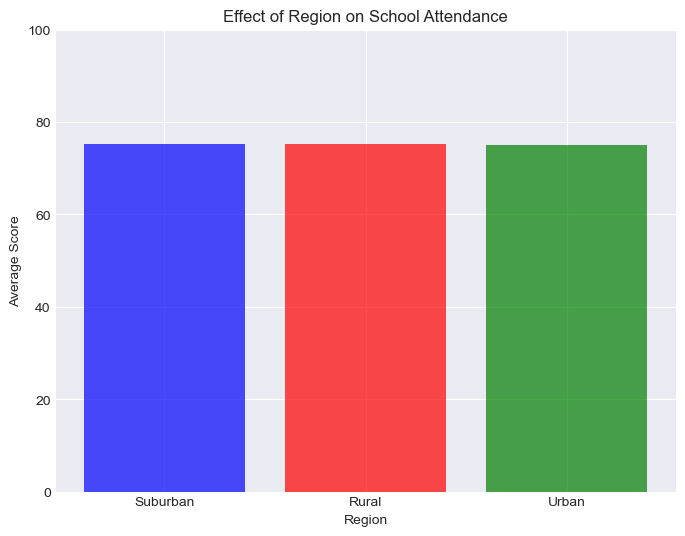

```python
statuses = ['Suburban', 'Rural', 'Urban']

plt.figure(figsize=(8,6))
bar_positions = np.arange(len(statuses))
plt.bar(bar_positions, region_att_avg, color = ['blue', 'red', 'green'], alpha=0.7)

plt.xticks(bar_positions, statuses)
plt.xlabel('Region')
plt.ylabel('Average Score')
plt.title('Effect of Region on School Attendance')
plt.ylim(0, 100)
plt.show()
```

## Age & Gender

```python
male_age_avg = round(Education[Education['Gender'] == 'Male']['Age'].mean(), 2)
female_age_avg = round(Education[Education['Gender'] == 'Female']['Age'].mean(), 2)

print("Average male age is:", male_age_avg)
print("Average female age is:", female_age_avg)
```

```
Average male age is: 15.96
Average female age is: 15.92
```

Average age of both genders has negligible difference

## Unique Age & Score

```python
uni = []
dup = []

for index, row in Education.iterrows():
    Age = row['Age']
    if Age in uni:
        dup.append(Age)
    else:
        uni.append(Age)

print(uni)
```

```
[16, 15, 17]
```

```
{'whiskers': [<matplotlib.lines.Line2D at 0x2a2400fbad0>,
 'caps': [<matplotlib.lines.Line2D at 0x2a2400fbfb0>,
 'boxes': [<matplotlib.lines.Line2D at 0x2a2400fb830>],
 'medians': [<matplotlib.lines.Line2D at 0x2a2401303e0>],
 'fliers': [<matplotlib.lines.Line2D at 0x2a240130620>],
 'means': []}
```

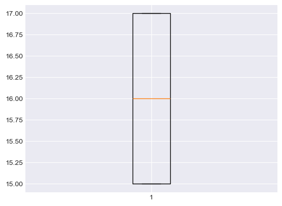

```python
plt.boxplot(x = 'Age', data = Education)
```

```python
Avg_score_15 = []
Avg_score_16 = []
Avg_score_17 = []
for index, row in Education.iterrows():
    Age = row['Age']
    Exam_Score = row['Exam_Score']
    if Age == 15:
        Avg_score_15.append(Exam_Score)
    elif Age == 16:
        Avg_score_16.append(Exam_Score)
    elif Age == 17:
        Avg_score_17.append(Exam_Score)

if Avg_score_15:
    average_score_15 = round(statistics.mean(Avg_score_15), 2)
if Avg_score_16:
    average_score_16 = round(statistics.mean(Avg_score_16), 2)
if Avg_score_17:
    average_score_17 = round(statistics.mean(Avg_score_17), 2)

print("Average score of 15 year olds is:", average_score_15)
print("Average score of 16 year olds is:", average_score_16)
print("Average score of 17 year olds is:", average_score_17)

unique_age_avg = (average_score_15, average_score_16, average_score_17)
```

```
Average score of 15 year olds is: 74.62
Average score of 16 year olds is: 76.49
Average score of 17 year olds is: 73.36
```

No noticable trend in the scores with respect to age. But the 17 year olds(oldest in the class) averaged noticably lower than others

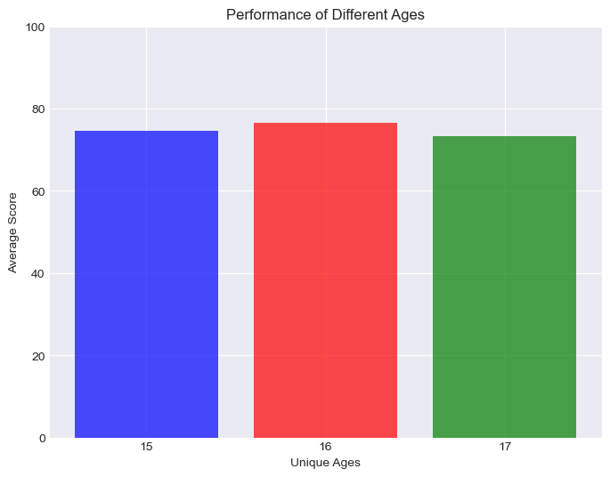

```python
statuses = [15,16,17]

plt.figure(figsize=(8,6))
bar_positions = np.arange(len(statuses))
plt.bar(bar_positions, unique_age_avg, color = ['blue', 'red', 'green'], alpha=0.7)

plt.xticks(bar_positions, statuses)
plt.xlabel('Unique Ages')
plt.ylabel('Average Score')
plt.title('Performance of Different Ages')
plt.ylim(0, 100)
plt.show()
```

# Unique Age & Attendance

```python
Avg_att_15 = []
Avg_att_16 = []
Avg_att_17 = []
for index, row in Education.iterrows():
    Age = row['Age']
    Attendance = row['Attendance (%)']
    if Age == 15:
        Avg_att_15.append(Attendance)
    elif Age == 16:
        Avg_att_16.append(Attendance)
    elif Age == 17:
        Avg_att_17.append(Attendance)

if Avg_att_15:
    average_att_15 = round(statistics.mean(Avg_att_15), 2)
if Avg_att_15:
    average_att_16 = round(statistics.mean(Avg_att_16), 2)
if Avg_att_15:
    average_att_17 = round(statistics.mean(Avg_att_17), 2)

print("Average attendance of 15 year olds is:", average_att_15)
print("Average attendance of 16 year olds is:", average_att_16)
print("Average attendance of 17 year olds is:", average_att_17)

unique_age_avg_att = (average_att_15, average_att_16, average_att_17)
```

```
Average attendance of 15 year olds is: 74.88
Average attendance of 16 year olds is: 75.81
Average attendance of 17 year olds is: 74.9
```

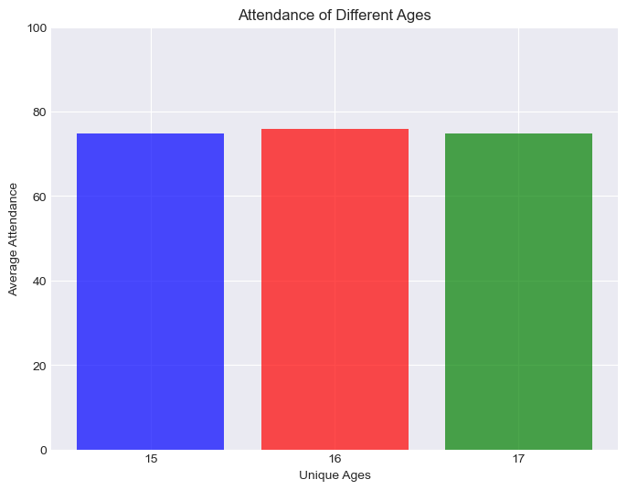

```python
statuses = [15,16,17]

plt.figure(figsize=(8,6))
bar_positions = np.arange(len(statuses))
plt.bar(bar_positions, unique_age_avg_att, color = ['blue', 'red', 'green'], alpha=0.7)

plt.xticks(bar_positions, statuses)
plt.xlabel('Unique Ages')
plt.ylabel('Average Attendance')
plt.title('Attendance of Different Ages')
plt.ylim(0, 100)
plt.show()
```

# Exam score and Attendance

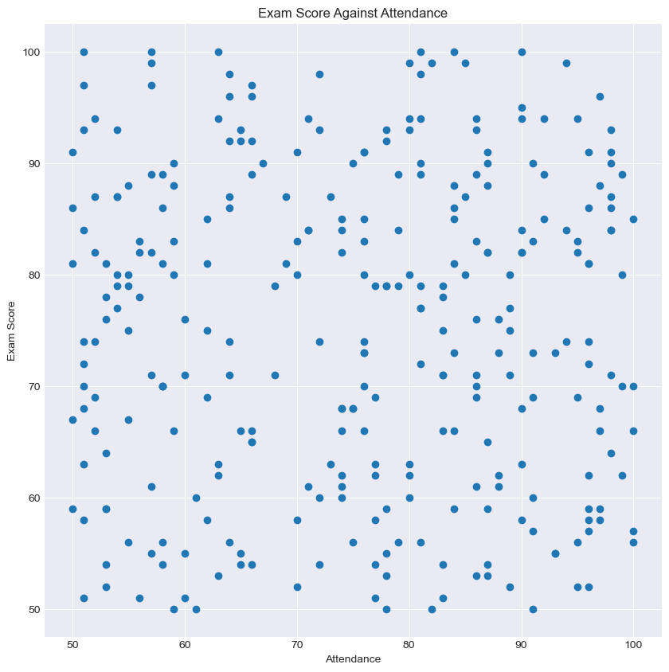

```python
# scattered plots
plt.figure(figsize = (10,10))
plt.scatter(x = 'Attendance (%)', y = 'Exam_Score', data = Education, marker = 'o')
plt.xlabel('Attendance')
plt.ylabel('Exam Score')
plt.title('Exam Score Against Attendance')
```